# Comparative Analysis of Clustering Algorithms

In this notebook we will compare K-means clustering to hierarchical clustering.

First, we make the necessary imports for the analysis

We don't know the dataset so let's familiarize ourselves with it using Pandas

|  | alcohol | malic_acid | ash | alcalinity_of_ash | magnesium | total_phenols | flavanoids | nonflavanoid_phenols | proanthocyanins | color_intensity | hue | od280/od315_of_diluted_wines | proline |
| --- | --- | --- | --- | --- | --- | --- | --- | --- | --- | --- | --- | --- | --- |
| 0 | 14.23 | 1.71 | 2.43 | 15.6 | 127.0 | 2.80 | 3.06 | 0.28 | 2.29 | 5.64 | 1.04 | 3.92 | 1065.0 |
| 1 | 13.20 | 1.78 | 2.14 | 11.2 | 100.0 | 2.65 | 2.76 | 0.26 | 1.28 | 4.38 | 1.05 | 3.40 | 1050.0 |
| 2 | 13.16 | 2.36 | 2.67 | 18.6 | 101.0 | 2.80 | 3.24 | 0.30 | 2.81 | 5.68 | 1.03 | 3.17 | 1185.0 |
| 3 | 14.37 | 1.95 | 2.50 | 16.8 | 113.0 | 3.85 | 3.49 | 0.24 | 2.18 | 7.80 | 0.86 | 3.45 | 1480.0 |
| 4 | 13.24 | 2.59 | 2.87 | 21.0 | 118.0 | 2.80 | 2.69 | 0.39 | 1.82 | 4.32 | 1.04 | 2.93 | 735.0 |

The different features represent chemical properties from spectroscopic analysis of the wine.

We see different features are of different scale - e.g. alcohol is %, magnesium is mg/L, so we must standardize the data.

|  | alcohol | malic_acid | ash | alcalinity_of_ash | magnesium | total_phenols | flavanoids | nonflavanoid_phenols | proanthocyanins | color_intensity | hue | od280/od315_of_diluted_wines | proline |
| --- | --- | --- | --- | --- | --- | --- | --- | --- | --- | --- | --- | --- | --- |
| 0 | 1.518613 | -0.562250 | 0.232053 | -1.169593 | 1.913905 | 0.808997 | 1.034819 | -0.659563 | 1.224884 | 0.251717 | 0.362177 | 1.847920 | 1.013009 |
| 1 | 0.246290 | -0.499413 | -0.827996 | -2.490847 | 0.018145 | 0.568648 | 0.733629 | -0.820719 | -0.544721 | -0.293321 | 0.406051 | 1.113449 | 0.965242 |
| 2 | 0.196879 | 0.021231 | 1.109334 | -0.268738 | 0.088358 | 0.808997 | 1.215533 | -0.498407 | 2.135968 | 0.269020 | 0.318304 | 0.788587 | 1.395148 |
| 3 | 1.691550 | -0.346811 | 0.487926 | -0.809251 | 0.930918 | 2.491446 | 1.466525 | -0.981875 | 1.032155 | 1.186068 | -0.427544 | 1.184071 | 2.334574 |
| 4 | 0.295700 | 0.227694 | 1.840403 | 0.451946 | 1.281985 | 0.808997 | 0.663351 | 0.226796 | 0.401404 | -0.319276 | 0.362177 | 0.449601 | -0.037874 |
| ... | ... | ... | ... | ... | ... | ... | ... | ... | ... | ... | ... | ... | ... |
| 173 | 0.876275 | 2.974543 | 0.305159 | 0.301803 | -0.332922 | -0.985614 | -1.424900 | 1.274310 | -0.930179 | 1.142811 | -1.392758 | -1.231206 | -0.021952 |
| 174 | 0.493343 | 1.412609 | 0.414820 | 1.052516 | 0.158572 | -0.793334 | -1.284344 | 0.549108 | -0.316950 | 0.969783 | -1.129518 | -1.485445 | 0.009893 |
| 175 | 0.332758 | 1.744744 | -0.389355 | 0.151661 | 1.422412 | -1.129824 | -1.344582 | 0.549108 | -0.422075 | 2.224236 | -1.612125 | -1.485445 | 0.280575 |
| 176 | 0.209232 | 0.227694 | 0.012732 | 0.151661 | 1.422412 | -1.033684 | -1.354622 | 1.354888 | -0.229346 | 1.834923 | -1.568252 | -1.400699 | 0.296498 |
| 177 | 1.395086 | 1.583165 | 1.365208 | 1.502943 | -0.262708 | -0.392751 | -1.274305 | 1.596623 | -0.422075 | 1.791666 | -1.524378 | -1.428948 | -0.595160 |

178 rows × 13 columns

Let's do some exploratory data analysis before we look at clustering

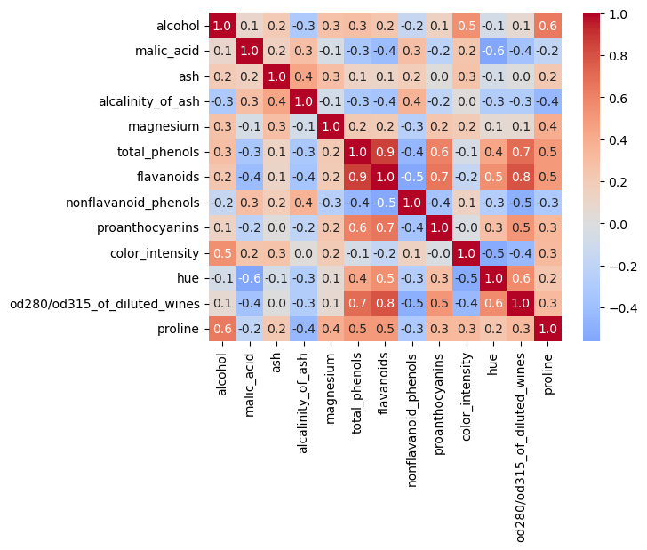

We see some strong positive correlations

- flavanoids & total_phenols (0.86)
- flavanoids & od280/od315_of_diluted_wines (0.79)
- total_phenols & od280/od315_of_diluted_wines (0.70)

Let's use flavanoids & total_phenols, and hue & color_intensity for a violin plot

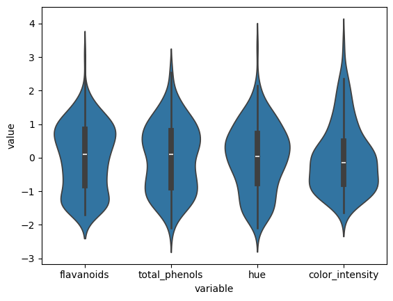

We see flavanoids and total_phenols have similar shapes, both wide at the top. This makes sense given their high correlation (0.86). Hue and color_intensity show opposite patterns - hue is wide at top, color_intensity wide at bottom - matching their negative correlation.

## K-means Clustering with k=3

```
KMeans(n_clusters=3, random_state=42)
```

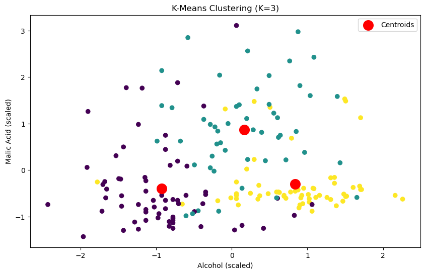

## Hierarchical Clustering (Agglomerative) n=3

```
AgglomerativeClustering(n_clusters=3)
```

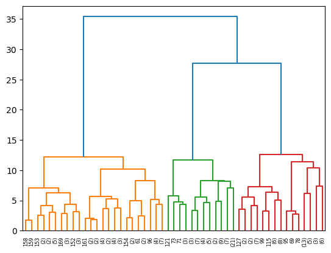

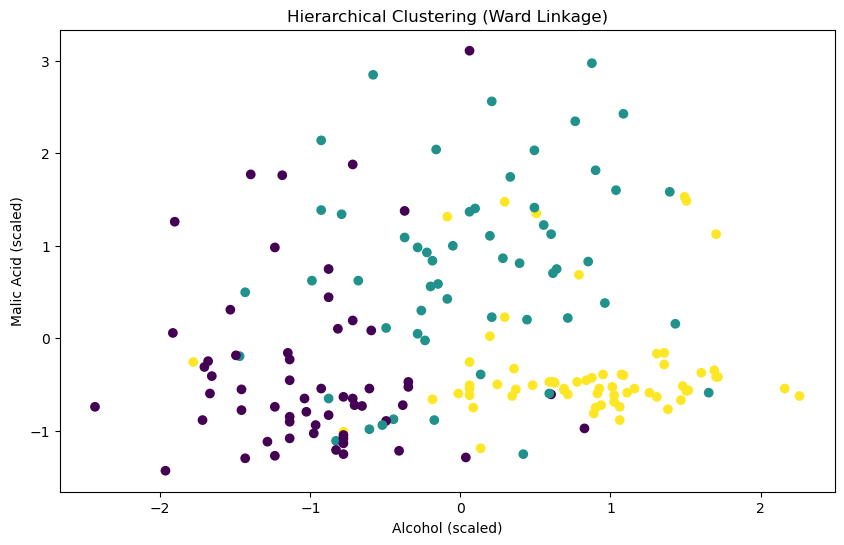

## Comparison 1 - Cluster Shape and Outliers

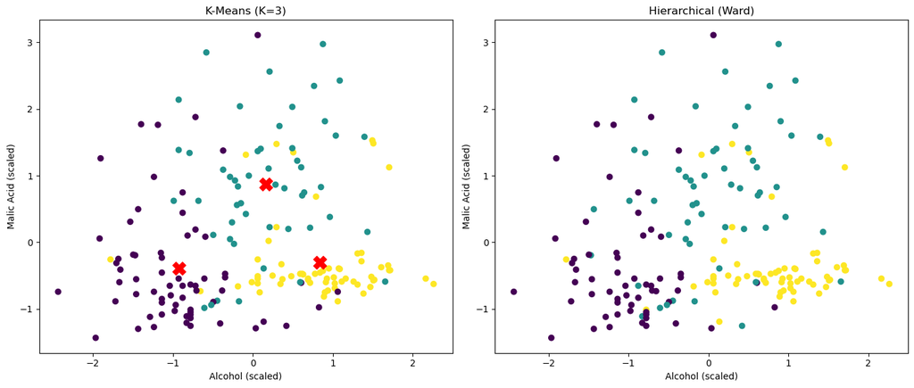

We see both models agree on the general structure of the clusters. Some ambiguous points may be assigned differently, but the overall clusters are similar. This is expected since Ward linkage minimizes variance and K-means minimizes squared distances - both favor compact clusters. K-means is more sensitive to outliers because they pull centroids away from the true cluster center.

## Comparison 2 - Initialization and Determinism

Let's run both of the algorithms multiple times to see if the cluster assignments change.

```
Run 1: label counts = [61 66 51]
Run 2: label counts = [62 65 51]
Run 3: label counts = [66 61 51]
```

```
Run 1: label counts = [58 56 64]
Run 2: label counts = [58 56 64]
Run 3: label counts = [58 56 64]
```

We see k-means algorithm produces different results each run due to random initialization, while hierarchical algorithm is deterministic. K-means can converge to local minima depending on starting centroids, which is why sklearn runs it multiple (10) times by default.

## Comparison 3 - Computational Complexity

Hierarchical clustering has complexity O(N^3), or O(N^2) with optimization. K-means has complexity O(KNI) — linear in N per iteration.

With N = 1,000,000 data points, K-means would require roughly 3 × 20 × 1,000,000 = 60 million operations. Hierarchical would require 1,000,000^2 = 1 trillion operations minimum.

Takeaway: For smaller datasets, hierarchical clustering is a good choice as it's deterministic and robust. For large datasets, K-means is preferable since it scales linearly with N, while hierarchical scales quadratically (or worse).

## Conclusion

Both algorithms found similar clusters in the wine dataset, which suggests the data has well-defined groupings. K-means is faster and scales better to large datasets, but requires careful initialization and is sensitive to outliers.

Hierarchical clustering is deterministic and lets you explore different numbers of clusters through the dendrogram, but becomes impractical for large datasets due to its quadratic complexity.

For this dataset (178 samples), either method works well. For millions of data points, K-means would be the clear choice.